# Titanic Survival Prediction

Oghenekeno Eribewe

2023-01-14

### Titanic Survival Predictions Using R

#### 2. Importing the data sets

The train set and test set are imported, the header is set to true as the data comes with each field having its own header. The strings as factors is set to false as we would be merging the two sets and performing some manipulations if required. It would be converted back to factors after whatever manipulation is carried out.

```r
t_train = read.csv("train.csv", header = T, stringsAsFactors = FALSE)
t_test = read.csv("test.csv", header = T, stringsAsFactors = FALSE)
```

#### 3. Basic stats and info on the data sets

A basic and descriptive information to help better understand the data sets is required so we can identify instances with missing or messy information, have an idea of the distribution of the values in the numerical fields, and how to got about handling missing values.

```r
# dimension of the data sets
dim(t_train)
```

```
## [1] 891  12
```

```r
dim(t_test)
```

```
## [1] 418  11
```

```r
# summary of the data sets
summary(t_train)
```

```
##   PassengerId       Survived          Pclass          Name
##  Min.   :  1.0   Min.   :0.0000   Min.   :1.000   Length:891
##  1st Qu.:223.5   1st Qu.:0.0000   1st Qu.:2.000   Class :character
##  Median :446.0   Median :0.0000   Median :3.000   Mode  :character
##  Mean   :446.0   Mean   :0.3838   Mean   :2.309
##  3rd Qu.:668.5   3rd Qu.:1.0000   3rd Qu.:3.000
##  Max.   :891.0   Max.   :1.0000   Max.   :3.000
##
##      Sex                 Age            SibSp           Parch
##  Length:891         Min.   : 0.42   Min.   :0.000   Min.   :0.0000
##  Class :character   1st Qu.:20.12   1st Qu.:0.000   1st Qu.:0.0000
##  Mode  :character   Median :28.00   Median :0.000   Median :0.0000
##                     Mean   :29.70   Mean   :0.523   Mean   :0.3816
##                     3rd Qu.:38.00   3rd Qu.:1.000   3rd Qu.:0.0000
##                     Max.   :80.00   Max.   :8.000   Max.   :6.0000
##                     NA's   :177
##     Ticket               Fare           Cabin             Embarked
##  Length:891         Min.   :  0.00   Length:891         Length:891
##  Class :character   1st Qu.:  7.91   Class :character   Class :character
##  Mode  :character   Median : 14.45   Mode  :character   Mode  :character
##                     Mean   : 32.20
##                     3rd Qu.: 31.00
##                     Max.   :512.33
##
```

```r
summary(t_test)
```

```
##   PassengerId         Pclass          Name               Sex
##  Min.   : 892.0   Min.   :1.000   Length:418         Length:418
##  1st Qu.: 996.2   1st Qu.:1.000   Class :character   Class :character
##  Median :1100.5   Median :3.000   Mode  :character   Mode  :character
##  Mean   :1100.5   Mean   :2.266
##  3rd Qu.:1204.8   3rd Qu.:3.000
##  Max.   :1309.0   Max.   :3.000
##
##       Age            SibSp            Parch           Ticket
##  Min.   : 0.17   Min.   :0.0000   Min.   :0.0000   Length:418
##  1st Qu.:21.00   1st Qu.:0.0000   1st Qu.:0.0000   Class :character
##  Median :27.00   Median :0.0000   Median :0.0000   Mode  :character
##  Mean   :30.27   Mean   :0.4474   Mean   :0.3923
##  3rd Qu.:39.00   3rd Qu.:1.0000   3rd Qu.:0.0000
##  Max.   :76.00   Max.   :8.0000   Max.   :9.0000
##  NA's   :86
##       Fare            Cabin             Embarked
##  Min.   :  0.000   Length:418         Length:418
##  1st Qu.:  7.896   Class :character   Class :character
##  Median : 14.454   Mode  :character   Mode  :character
##  Mean   : 35.627
##  3rd Qu.: 31.500
##  Max.   :512.329
##  NA's   :1
```

In the training set, there are 891 observations with 12 variables/fields. The Age field contains 177 instances with missing values. In the test set, there are 418 observations with 11 variables/fields as the Survived field in the training set is what we want to predict in the test set. The Age field in the test set contains 86 instances with missing values, and the Fare field has 1 instance with missing value.

#### 4. Creating a new field in both data sets to differentiate train from test set

We intend to merge the training set and the test set into one data set to perform some cleaning tasks and so we want to be able to differentiate the sets so we can easily separate them when it gets to building the models. So, we create a new field in the two sets called isTrain which is either true or false.

```r
t_train$isTrain = TRUE
t_test$isTrain = FALSE
```

#### 5. Creating a survived field in the test set

In the test set, we need to create the Survived field which is in the training set as merging can only be done with data sets containing the same number of variables/fields. And, we fill this field with NA’s.

```r
t_test$Survived = NA
```

#### 6. Merging the two data sets into one

```r
t_full = rbind(t_train, t_test)

# basic view of the combined data set
#View(t_full)
head(t_full, 5) # top five instances
```

```
##   PassengerId Survived Pclass
## 1           1        0      3
## 2           2        1      1
## 3           3        1      3
## 4           4        1      1
## 5           5        0      3
##                                                  Name    Sex Age SibSp Parch
## 1                             Braund, Mr. Owen Harris   male  22     1     0
## 2 Cumings, Mrs. John Bradley (Florence Briggs Thayer) female  38     1     0
## 3                              Heikkinen, Miss. Laina female  26     0     0
## 4        Futrelle, Mrs. Jacques Heath (Lily May Peel) female  35     1     0
## 5                            Allen, Mr. William Henry   male  35     0     0
##             Ticket    Fare Cabin Embarked isTrain
## 1        A/5 21171  7.2500              S    TRUE
## 2         PC 17599 71.2833   C85        C    TRUE
## 3 STON/O2. 3101282  7.9250              S    TRUE
## 4           113803 53.1000  C123        S    TRUE
## 5           373450  8.0500              S    TRUE
```

```r
tail(t_full, 5) # bottom five instances
```

```
##      PassengerId Survived Pclass                         Name    Sex  Age SibSp
## 1305        1305       NA      3           Spector, Mr. Woolf   male   NA     0
## 1306        1306       NA      1 Oliva y Ocana, Dona. Fermina female 39.0     0
## 1307        1307       NA      3 Saether, Mr. Simon Sivertsen   male 38.5     0
## 1308        1308       NA      3          Ware, Mr. Frederick   male   NA     0
## 1309        1309       NA      3     Peter, Master. Michael J   male   NA     1
##      Parch             Ticket     Fare Cabin Embarked isTrain
## 1305     0          A.5. 3236   8.0500              S   FALSE
## 1306     0           PC 17758 108.9000  C105        C   FALSE
## 1307     0 SOTON/O.Q. 3101262   7.2500              S   FALSE
## 1308     0             359309   8.0500              S   FALSE
## 1309     1               2668  22.3583              C   FALSE
```

```r
# basic stats
summary(t_full)
```

```
##   PassengerId      Survived          Pclass          Name
##  Min.   :   1   Min.   :0.0000   Min.   :1.000   Length:1309
##  1st Qu.: 328   1st Qu.:0.0000   1st Qu.:2.000   Class :character
##  Median : 655   Median :0.0000   Median :3.000   Mode  :character
##  Mean   : 655   Mean   :0.3838   Mean   :2.295
##  3rd Qu.: 982   3rd Qu.:1.0000   3rd Qu.:3.000
##  Max.   :1309   Max.   :1.0000   Max.   :3.000
##                 NA's   :418
##      Sex                 Age            SibSp            Parch
##  Length:1309        Min.   : 0.17   Min.   :0.0000   Min.   :0.000
##  Class :character   1st Qu.:21.00   1st Qu.:0.0000   1st Qu.:0.000
##  Mode  :character   Median :28.00   Median :0.0000   Median :0.000
##                     Mean   :29.88   Mean   :0.4989   Mean   :0.385
##                     3rd Qu.:39.00   3rd Qu.:1.0000   3rd Qu.:0.000
##                     Max.   :80.00   Max.   :8.0000   Max.   :9.000
##                     NA's   :263
##     Ticket               Fare            Cabin             Embarked
##  Length:1309        Min.   :  0.000   Length:1309        Length:1309
##  Class :character   1st Qu.:  7.896   Class :character   Class :character
##  Mode  :character   Median : 14.454   Mode  :character   Mode  :character
##                     Mean   : 33.295
##                     3rd Qu.: 31.275
##                     Max.   :512.329
##                     NA's   :1
##   isTrain
##  Mode :logical
##  FALSE:418
##  TRUE :891
##
##
##
##
```

#### 7. Basic info of the combined data set

```r
head(t_full, 5) # top five instances
```

```
##   PassengerId Survived Pclass
## 1           1        0      3
## 2           2        1      1
## 3           3        1      3
## 4           4        1      1
## 5           5        0      3
##                                                  Name    Sex Age SibSp Parch
## 1                             Braund, Mr. Owen Harris   male  22     1     0
## 2 Cumings, Mrs. John Bradley (Florence Briggs Thayer) female  38     1     0
## 3                              Heikkinen, Miss. Laina female  26     0     0
## 4        Futrelle, Mrs. Jacques Heath (Lily May Peel) female  35     1     0
## 5                            Allen, Mr. William Henry   male  35     0     0
##             Ticket    Fare Cabin Embarked isTrain
## 1        A/5 21171  7.2500              S    TRUE
## 2         PC 17599 71.2833   C85        C    TRUE
## 3 STON/O2. 3101282  7.9250              S    TRUE
## 4           113803 53.1000  C123        S    TRUE
## 5           373450  8.0500              S    TRUE
```

```r
tail(t_full, 5) # bottom five instances
```

```
##      PassengerId Survived Pclass                         Name    Sex  Age SibSp
## 1305        1305       NA      3           Spector, Mr. Woolf   male   NA     0
## 1306        1306       NA      1 Oliva y Ocana, Dona. Fermina female 39.0     0
## 1307        1307       NA      3 Saether, Mr. Simon Sivertsen   male 38.5     0
## 1308        1308       NA      3          Ware, Mr. Frederick   male   NA     0
## 1309        1309       NA      3     Peter, Master. Michael J   male   NA     1
##      Parch             Ticket     Fare Cabin Embarked isTrain
## 1305     0          A.5. 3236   8.0500              S   FALSE
## 1306     0           PC 17758 108.9000  C105        C   FALSE
## 1307     0 SOTON/O.Q. 3101262   7.2500              S   FALSE
## 1308     0             359309   8.0500              S   FALSE
## 1309     1               2668  22.3583              C   FALSE
```

```r
# basic stats
summary(t_full)
```

```
##   PassengerId      Survived          Pclass          Name
##  Min.   :   1   Min.   :0.0000   Min.   :1.000   Length:1309
##  1st Qu.: 328   1st Qu.:0.0000   1st Qu.:2.000   Class :character
##  Median : 655   Median :0.0000   Median :3.000   Mode  :character
##  Mean   : 655   Mean   :0.3838   Mean   :2.295
##  3rd Qu.: 982   3rd Qu.:1.0000   3rd Qu.:3.000
##  Max.   :1309   Max.   :1.0000   Max.   :3.000
##                 NA's   :418
##      Sex                 Age            SibSp            Parch
##  Length:1309        Min.   : 0.17   Min.   :0.0000   Min.   :0.000
##  Class :character   1st Qu.:21.00   1st Qu.:0.0000   1st Qu.:0.000
##  Mode  :character   Median :28.00   Median :0.0000   Median :0.000
##                     Mean   :29.88   Mean   :0.4989   Mean   :0.385
##                     3rd Qu.:39.00   3rd Qu.:1.0000   3rd Qu.:0.000
##                     Max.   :80.00   Max.   :8.0000   Max.   :9.000
##                     NA's   :263
##     Ticket               Fare            Cabin             Embarked
##  Length:1309        Min.   :  0.000   Length:1309        Length:1309
##  Class :character   1st Qu.:  7.896   Class :character   Class :character
##  Mode  :character   Median : 14.454   Mode  :character   Mode  :character
##                     Mean   : 33.295
##                     3rd Qu.: 31.275
##                     Max.   :512.329
##                     NA's   :1
##   isTrain
##  Mode :logical
##  FALSE:418
##  TRUE :891
##
##
##
##
```

### Data Cleaning

#### 8. Working on fields with missing values

After combining the data sets, we now have a data set with 1309 observations and 13 variables/fields. We need to clean the data to ensure it’s ready for modelling. And so, we look at fields that require the cleaning individually.

**Age**: The Age field contains 263 missing values in total. We visualize the distribution of ages of the passengers on board the titanic (omitting the instances with NA) using a histogram from the ggplot library.

```r
# stats of the age column
summary(t_full$Age)
```

```
##    Min. 1st Qu.  Median    Mean 3rd Qu.    Max.    NA's
##    0.17   21.00   28.00   29.88   39.00   80.00     263
```

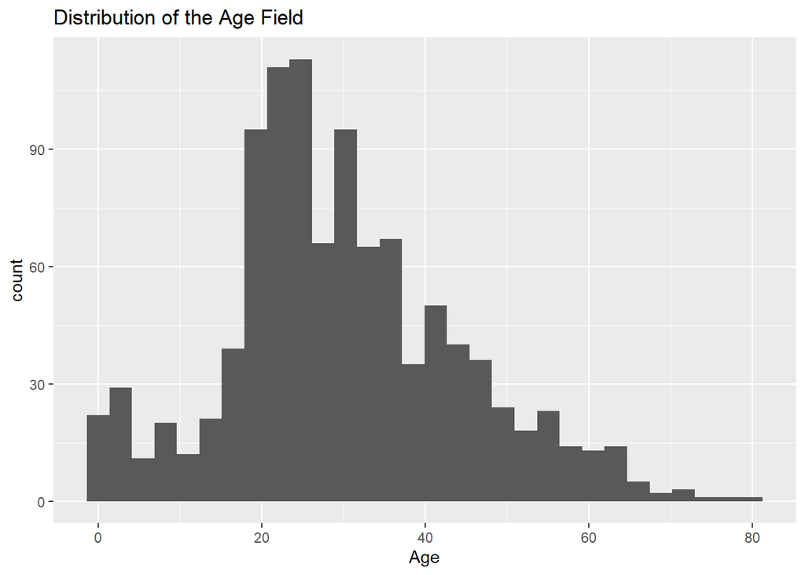

```r
# visual of the age column
ggplot(t_full, aes(x = Age)) + geom_histogram(bins = 30, na.rm = T) + labs(title = "Distribution of the Age Field")
```

```r
# imputing the median of the Age field
x = impute(t_full$Age, median)
summary(x)
```

```
##
##  263 values imputed to 28
```

```
##    Min. 1st Qu.  Median    Mean 3rd Qu.    Max.
##    0.17   22.00   28.00   29.50   35.00   80.00
```

```r
# imputing back into the data set
t_full$Age = x
```

From the histogram, the distribution of ages of passengers seems a bit right-skewed and so we could consider replacing the NA’s with the median of the field.

**Fare**: The fare field contains just 1 instance with a missing value and so we could consider dropping the instance or we could look at the distribution and then impute a value but it wold make no difference.

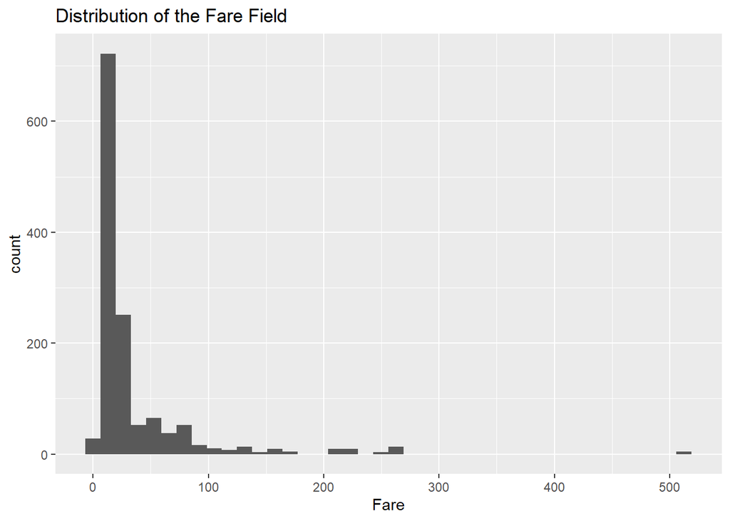

```r
# dealing with Fares
ggplot(t_full, aes(x = Fare)) + geom_histogram(bins = 40, na.rm = T) +
  labs(title = "Distribution of the Fare Field")
```

```r
summary(t_full$Fare)
```

```
##    Min. 1st Qu.  Median    Mean 3rd Qu.    Max.    NA's
##   0.000   7.896  14.454  33.295  31.275 512.329       1
```

```r
# imputing the median of the Fare field
y = impute(t_full$Fare, median)
summary(y)
```

```
##
##  1 values imputed to 14.4542
```

```
##    Min. 1st Qu.  Median    Mean 3rd Qu.    Max.
##   0.000   7.896  14.454  33.281  31.275 512.329
```

```r
# imputing back into the data set
t_full$Fare = y
```

From the histogram, the distribution of the passenger fare is right-skewed with an outlier of 512 and so we could consider replacing the NA’s with the median of the field.

```r
summary(t_full$Embarked)
```

```
##    Length     Class      Mode
##      1309 character character
```

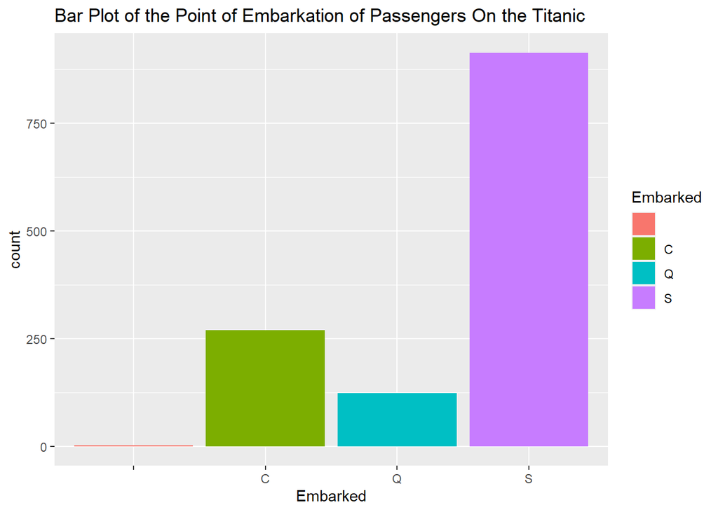

```r
# replacing with the mode
ggplot(t_full, aes(x = Embarked, fill = Embarked)) + geom_bar() + labs(title = "Bar Plot of the Point of Embarkation of Passengers On the Titanic")
```

```r
x = t_full$Embarked
x[t_full$Embarked == ''] = NA
x = impute(x, mode)
x = droplevels.factor(x)
summary(x)
```

```
##         C character         Q         S
##       270         2       123       914
```

```r
t_full$Embarked = x
summary(t_full$Embarked)
```

```
##         C character         Q         S
##       270         2       123       914
```

#### 9. Categorical Casting

We cast all the fields that are actually categories as factors excluding the Survived field which has NA’s and so would mess up the category which is supposed to be binary categories and it shouldn’t even exist in the test set.

```r
t_full$Sex = as.factor(t_full$Sex)
t_full$Pclass = as.factor(t_full$Pclass)
t_full$Cabin = as.factor(t_full$Cabin)
t_full$Embarked = as.factor(t_full$Embarked)
```

#### 10. Removing the irrelevant fields

Fields like the Name, and Ticket Number have no predictive value that would be useful in modelling. The Name and Ticket number field contain unique instances.

```r
# dropping the name field
t_full$Name = NULL

# dropping the ticket number field
t_full$Ticket = NULL
```

```r
# summary of the full data set
summary(t_full)
```

```
##
##  263 values imputed to 28
##
##
##  1 values imputed to 14.4542
```

```
##   PassengerId      Survived      Pclass      Sex           Age
##  Min.   :   1   Min.   :0.0000   1:323   female:466   Min.   : 0.17
##  1st Qu.: 328   1st Qu.:0.0000   2:277   male  :843   1st Qu.:22.00
##  Median : 655   Median :0.0000   3:709                Median :28.00
##  Mean   : 655   Mean   :0.3838                        Mean   :29.50
##  3rd Qu.: 982   3rd Qu.:1.0000                        3rd Qu.:35.00
##  Max.   :1309   Max.   :1.0000                        Max.   :80.00
##                 NA's   :418
##      SibSp            Parch            Fare                     Cabin
##  Min.   :0.0000   Min.   :0.000   Min.   :  0.000                  :1014
##  1st Qu.:0.0000   1st Qu.:0.000   1st Qu.:  7.896   C23 C25 C27    :   6
##  Median :0.0000   Median :0.000   Median : 14.454   B57 B59 B63 B66:   5
##  Mean   :0.4989   Mean   :0.385   Mean   : 33.281   G6             :   5
##  3rd Qu.:1.0000   3rd Qu.:0.000   3rd Qu.: 31.275   B96 B98        :   4
##  Max.   :8.0000   Max.   :9.000   Max.   :512.329   C22 C26        :   4
##                                                     (Other)        : 271
##       Embarked    isTrain
##  C        :270   Mode :logical
##  character:  2   FALSE:418
##  Q        :123   TRUE :891
##  S        :914
##
##
##
```

#### 11. The fields SibSp and Parch

The number of siblings/spouses aboard the titanic ranges from 0 - 8 which seems to be categorical, so it would be ideal to cast the data type of the field as a category (factor). Same with the Parch field, it ranges from 0 - 9 and as such should be cast as categories (factor). Both fields are not required for any numerical calculation.

```r
t_full$SibSp = as.factor(t_full$SibSp)
t_full$Parch = as.factor(t_full$Parch)

summary(t_full$SibSp)
```

```
##   0   1   2   3   4   5   8
## 891 319  42  20  22   6   9
```

```r
summary(t_full$Parch)
```

```
##    0    1    2    3    4    5    6    9
## 1002  170  113    8    6    6    2    2
```

#### 12. Splitting the data set back into the train and test set

Next, we split the data set back into the train and test set.

```r
# train set
t_train1 = t_full[t_full$isTrain == TRUE, ]
# dropping the created isTrain field
t_train1$isTrain = NULL

# test set
t_test1 = t_full[t_full$isTrain == FALSE, ]
# dropping the created isTrain field
t_test1$isTrain = NULL
```

### EDA (Exploratory Data Analysis)

We would be exploring the fields in the train set to draw up questions, and key insights using visualizations to aid the understanding of this data set.

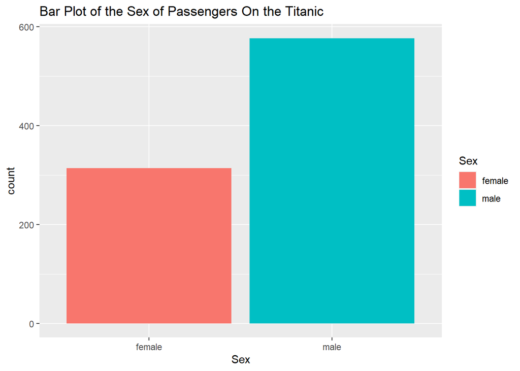

```r
# Bar Plot of the Sex of Passengers On the Titanic
ggplot(t_train1, aes(x = Sex, fill = Sex)) + geom_bar() + labs(title = "Bar Plot of the Sex of Passengers On the Titanic")
```

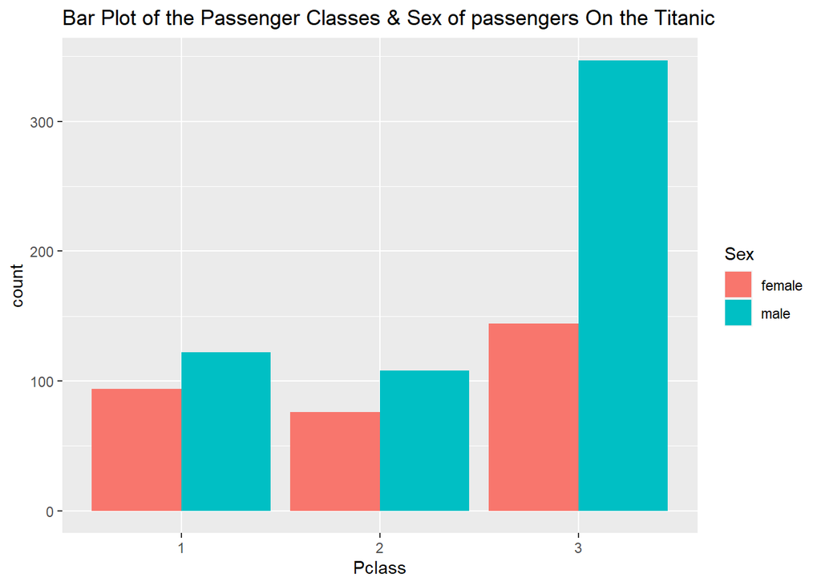

```r
# Bar Plot of the Passenger Classes & Sex of passengers On the Titanic
ggplot(t_train1, aes(x = Pclass, fill = Sex)) + geom_bar(position = "dodge") + labs(title = "Bar Plot of the Passenger Classes & Sex of passengers On the Titanic")
```

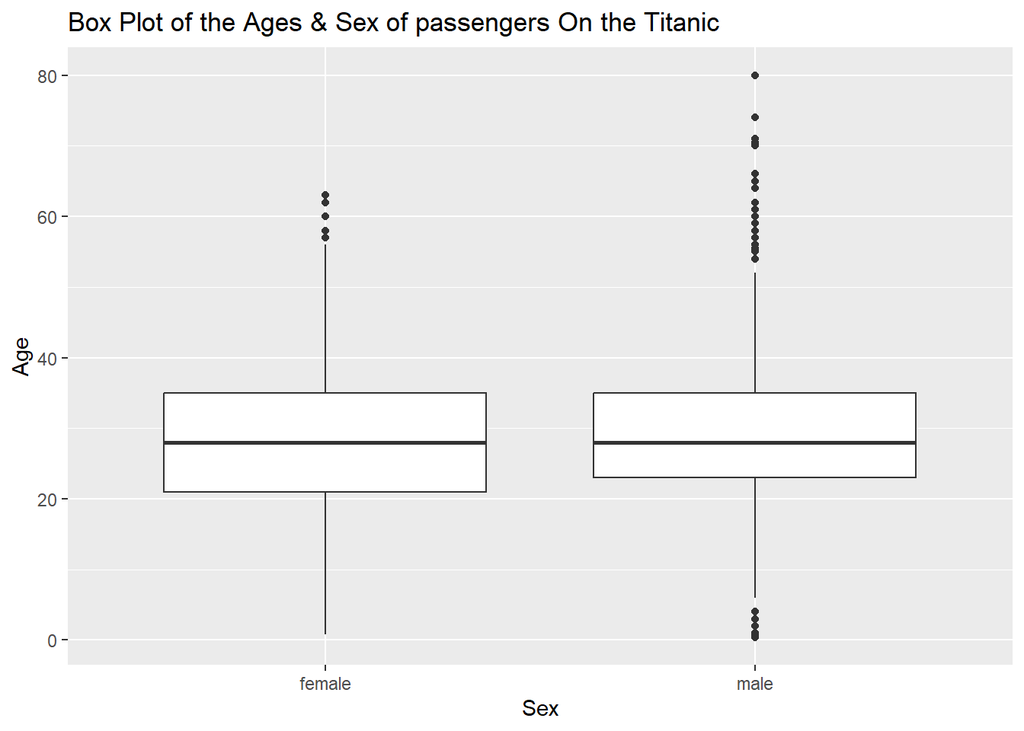

```r
# Box Plot of the Ages & Sex of passengers On the Titanic
ggplot(t_train1, aes(x = Sex, y = Age)) + geom_boxplot() + labs(title = "Box Plot of the Ages & Sex of passengers On the Titanic")
```

We want to explore the effect of some key variables on the outcome (Survived). The Survived variable/field needs to be cast as factor as it is a binary classification ( 0 - False, 1 - True).

```r
t_train1$Survived = as.factor(t_train1$Survived)

summary(t_train1$Survived)
```

```
##   0   1
## 549 342
```

##### Effect of Age on the Survival of passengers on the titanic

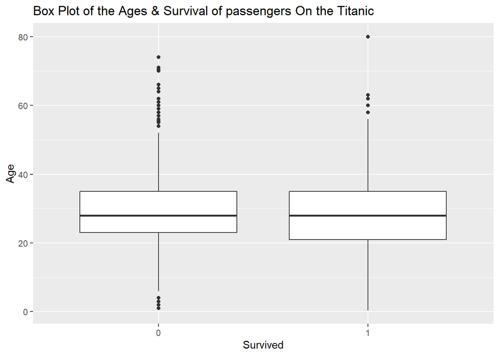

```r
# Box Plot of the Ages & Survival of passengers on the Titanic
ggplot(t_train1, aes(x = Survived, y = Age)) + geom_boxplot() + labs(title = "Box Plot of the Ages & Survival of passengers On the Titanic")
```

#### Survival of the Siblings/Spouse category

```r
# table showing the survival rate of Siblings/Spouse
ftable(xtabs(~Survived+SibSp, data = t_train1))
```

```
##          SibSp   0   1   2   3   4   5   8
## Survived
## 0              398  97  15  12  15   5   7
## 1              210 112  13   4   3   0   0
```

#### Survival of the Parents/Children category

```r
# table showing the survival rate of Parents/Children
ftable(xtabs(~Survived+Parch, data = t_train1))
```

```
##          Parch   0   1   2   3   4   5   6   9
## Survived
## 0              445  53  40   2   4   4   1   0
## 1              233  65  40   3   0   1   0   0
```

The cabin field doesn’t seem to be useful and so we remove it.

```r
summary(t_train1$Cabin)
```

```
##                         B96 B98     C23 C25 C27              G6         C22 C26
##             687               4               4               4               3
##               D            E101              F2             F33             B18
##               3               3               3               3               2
##             B20             B22             B28             B35             B49
##               2               2               2               2               2
##              B5     B51 B53 B55 B57 B59 B63 B66         B58 B60             B77
##               2               2               2               2               2
##            C123            C124            C125            C126              C2
##               2               2               2               2               2
##             C52             C65             C68             C78             C83
##               2               2               2               2               2
##             C92             C93             D17             D20             D26
##               2               2               2               2               2
##             D33             D35             D36            E121             E24
##               2               2               2               2               2
##             E25             E33             E44             E67              E8
##               2               2               2               2               2
##           F G73              F4             A10             A14             A16
##               2               2               1               1               1
##             A19             A20             A23             A24             A26
##               1               1               1               1               1
##             A31             A32             A34             A36              A5
##               1               1               1               1               1
##              A6              A7            B101            B102             B19
##               1               1               1               1               1
##              B3             B30             B37             B38             B39
##               1               1               1               1               1
##              B4             B41             B42             B50             B69
##               1               1               1               1               1
##             B71             B73             B78             B79             B80
##               1               1               1               1               1
##         B82 B84             B86             B94            C101            C103
##               1               1               1               1               1
##            C104            C106            C110            C111            C118
##               1               1               1               1               1
##            C128            C148             C30             C32             C45
##               1               1               1               1               1
##             C46             C47             C49             C50         (Other)
##               1               1               1               1              49
```

```r
# dropping the Cabin field
t_train1$Cabin = NULL
```

**Survival rate of passengers point of embarkation**

```r
summary(t_train1$Embarked)
```

```
##         C character         Q         S
##       168         2        77       644
```

```r
# table showing the survival rate of passengers point of embarkment
ftable(xtabs(~Survived+Embarked, data = t_train1))
```

```
##          Embarked   C character   Q   S
## Survived
## 0                  75         0  47 427
## 1                  93         2  30 217
```

#### Data Modelling: Classification Models

Creating a train - test split

```r
# setting the seed to ensure reproducibility of results
set.seed(123)
trsplit = createDataPartition(t_train1$Survived, p = 0.7, list = F)
tr = t_train1[trsplit,]
te = t_train1[-trsplit,]
# setting up caret evaluation method
ctrl = trainControl(method = "repeatedcv", number = 5, repeats = 3)
```

We apply C5.0Tree algorithm to predict the passengers survival using all other fields except the PassengerId which is of no benefit but will be needed to identify each passenger using caret evaluation method to carry out 3 repeats of 5-fold cross-validation.

```r
set.seed(123)
# Fit a model using all the variables
modelA = train(Survived ~ Pclass+Sex+Age+SibSp+Parch+Fare+Embarked, data = tr,
 method = "C5.0Tree", trControl = ctrl)

# summary of results
summary(modelA)
```

```
##
## Call:
## C50:::C5.0.default(x = x, y = y, weights = wts)
##
##
## C5.0 [Release 2.07 GPL Edition]      Sat Jan 14 02:54:07 2023
## -------------------------------
##
## Class specified by attribute `outcome'
##
## Read 625 cases (22 attributes) from undefined.data
##
## Decision tree:
##
## Sexmale <= 0:
## :...Pclass3 <= 0: 1 (122/6)
## :   Pclass3 > 0:
## :   :...Fare <= 23.25: 1 (84/33)
## :       Fare > 23.25: 0 (17/1)
## Sexmale > 0:
## :...Age <= 13:
##     :...SibSp1 <= 0: 0 (14/4)
##     :   SibSp1 > 0: 1 (9)
##     Age > 13:
##     :...Fare <= 26.25: 0 (288/28)
##         Fare > 26.25:
##         :...Pclass2 > 0: 0 (9)
##             Pclass2 <= 0:
##             :...Parch1 > 0: 0 (11/1)
##                 Parch1 <= 0:
##                 :...SibSp1 <= 0:
##                     :...Fare <= 30.5: 1 (19/6)
##                     :   Fare > 30.5: 0 (35/8)
##                     SibSp1 > 0:
##                     :...EmbarkedS <= 0: 1 (6/1)
##                         EmbarkedS > 0: 0 (11/4)
##
##
## Evaluation on training data (625 cases):
##
```

[output cut: 11 more lines]

```
##
##
##  Attribute usage:
##
##  100.00% Sexmale
##   76.80% Fare
##   64.32% Age
##   35.68% Pclass3
##   15.04% SibSp1
##   14.56% Pclass2
##   13.12% Parch1
##    2.72% EmbarkedS
##
##
## Time: 0.0 secs
```

```r
modelA$results
```

```
##   parameter  Accuracy     Kappa AccuracySD    KappaSD
## 1      none 0.8165333 0.6039631 0.02465148 0.05766496
```

```r
pred = predict(modelA, te)
confusionMatrix(pred, te$Survived)
```

```
## Confusion Matrix and Statistics
##
##           Reference
## Prediction   0   1
##          0 135  29
##          1  29  73
##
##                Accuracy : 0.782
##                  95% CI : (0.7274, 0.8301)
##     No Information Rate : 0.6165
##     P-Value [Acc > NIR] : 5.932e-09
##
##                   Kappa : 0.5389
##
##  Mcnemar's Test P-Value : 1
##
##             Sensitivity : 0.8232
##             Specificity : 0.7157
##          Pos Pred Value : 0.8232
##          Neg Pred Value : 0.7157
##              Prevalence : 0.6165
##          Detection Rate : 0.5075
##    Detection Prevalence : 0.6165
##       Balanced Accuracy : 0.7694
##
##        'Positive' Class : 0
##
```

The C5.0Tree predicted 78.2% accurately. We would apply random forest algorithm to see if it gives us a better result still using the evaluation method set up already and then use the more accurate one to predict on the actual test set.

```r
set.seed(123)
# Fit a model using all the variables
modelB = train(Survived ~ Pclass+Sex+Age+SibSp+Parch+Fare+Embarked, method = "rf", metric = "Accuracy", data = tr, trControl = ctrl)

# summary of results
modelB$results
```

```
##   mtry  Accuracy     Kappa AccuracySD    KappaSD
## 1    2 0.8090667 0.5655807 0.03021699 0.07592841
## 2   11 0.8325333 0.6408613 0.02126656 0.04379833
## 3   21 0.8181333 0.6125122 0.02148045 0.04630932
```

```r
pred1 = predict(modelB, te)
confusionMatrix(pred1, te$Survived)
```

```
## Confusion Matrix and Statistics
##
##           Reference
## Prediction   0   1
##          0 138  26
##          1  26  76
##
##                Accuracy : 0.8045
##                  95% CI : (0.7517, 0.8504)
##     No Information Rate : 0.6165
##     P-Value [Acc > NIR] : 3.037e-11
##
##                   Kappa : 0.5866
##
##  Mcnemar's Test P-Value : 1
##
##             Sensitivity : 0.8415
##             Specificity : 0.7451
##          Pos Pred Value : 0.8415
##          Neg Pred Value : 0.7451
##              Prevalence : 0.6165
##          Detection Rate : 0.5188
##    Detection Prevalence : 0.6165
##       Balanced Accuracy : 0.7933
##
##        'Positive' Class : 0
##
```

We have a higher accuracy using the random forest and then the error is a bit minimal as compared to C5.0Tree.

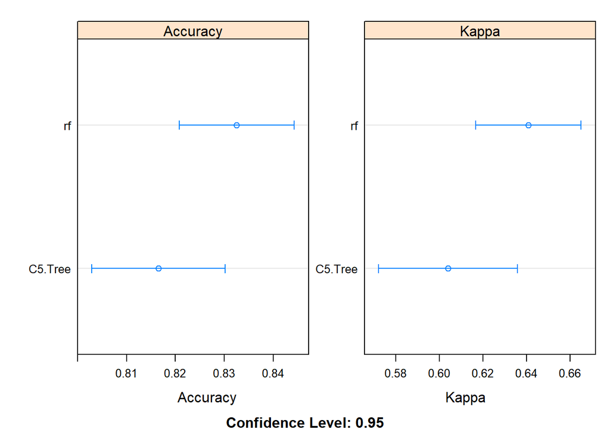

```r
confint = resamples(list(C5.Tree = modelA, rf = modelB))
dotplot(confint, conf.level = 0.95, scales = "free")
```

From the visual above, random forest performs better and we will use it to predict the survival of the passengers in the test set.

#### Predicting the Survival of Passengers in the Test set

```r
# predicting the survival
Survived = predict(modelB, t_test1)
```

```r
# based on the format of kaggle submission, we need only 2 columns
PassengerId = t_test1$PassengerId
output.df = as.data.frame(PassengerId)
output.df$Survived = Survived
#View(output.df)
```

#### Storing the solution into a CSV file

```r
write.csv(output.df, file = "Kaggle_Submission.csv", row.names = FALSE)
```